# Project of EU with spatial data

Shuai Hu & Jin Huang

2024

## Introduction

The poverty rate is a measure used to assess the degree of poverty within a specific region, group, or country. It is typically expressed as a percentage, representing the proportion of the population in a state of poverty over the total population during a certain period. The poverty rate is a crucial indicator in the fields of poverty research and socio-economic development. It aids in evaluating the extent of poverty, formulating poverty alleviation policies, and monitoring the fairness of socio-economic conditions.

The poverty rate is a problem faced by the whole world. This time we focus on the causal relationship between the poverty rate and related independent variables in EU countries in 2011 and 2020 (to maintain data integrity, the data does not include the United Kingdom) and conduct Simple spatial data analysis.

## Prepareing the data

### Loading the packages

[output not shown]

### Loading the data

```r
options(scipen = 10)
poverty_data <- read.csv("poverty.csv")
minimumWage <- read.csv("minimumWage.csv")
Overcrowding_rate <- read.csv("Overcrowding rate.csv")
unemployment_rate <- read.csv("unemployment rate.csv")
length(Overcrowding_rate)
```

```
## [1] 13
```

```r
EU <- st_read("Europe_merged.shp")
world <- ne_countries(scale = "medium", returnclass = "sf")
europe <- world %>%
  filter(continent == 'Europe')
```

```r
europe <- europe %>%
  mutate(name = case_when(
    name == "Czech Rep." ~ "Czechia",
    TRUE ~ name
  ))
```

```r
EU1<- europe[europe$name %in% c("Austria", "Belgium","Bulgaria","Croatia","Cyprus","Czechia","Denmark","Estonia","Finland","France"
                                ,"Germany","Greece","Hungary","Ireland","Italy","Latvia","Lithuania"
                                ,"Luxembourg","Malta","Netherlands","Poland","Portugal","Romania","Slovakia"
                                ,"Slovenia","Spain","Sweden"), ]

cyprus_data <- world[world$name == "Cyprus",]
```

```r
EU1 <- rbind(EU1, cyprus_data)
EU1$name
```

```
##  [1] "Austria"     "Belgium"     "Bulgaria"    "Czechia"     "Germany"
##  [6] "Denmark"     "Spain"       "Estonia"     "Finland"     "France"
## [11] "Greece"      "Croatia"     "Hungary"     "Ireland"     "Italy"
## [16] "Lithuania"   "Luxembourg"  "Latvia"      "Malta"       "Netherlands"
## [21] "Poland"      "Portugal"    "Romania"     "Slovakia"    "Slovenia"
## [26] "Sweden"      "Cyprus"
```

```r
poverty_data <- poverty_data %>% select(Country, X2011, X2020)
minimumWage <- minimumWage %>% select(Country, X2011, X2020)
Overcrowding_rate <- Overcrowding_rate %>% select(TIME, X2011, X2020)
unemployment_rate <- unemployment_rate %>% select(TIME, X2011, X2020)

names(poverty_data) <- gsub("X", "", names(poverty_data))
names(minimumWage) <- gsub("X", "", names(poverty_data))
names(Overcrowding_rate) <- gsub("X", "", names(poverty_data))
names(unemployment_rate) <- gsub("X", "", names(poverty_data))

poverty_data <- poverty_data %>% rename(poverty_data_2011 = "2011",poverty_data_2020 = "2020")
minimumWage <- minimumWage %>% rename(minimumWage_2011 = "2011",minimumWage_2020 = "2020")
Overcrowding_rate <- Overcrowding_rate %>% rename(Overcrowding_rate_2011 = "2011",Overcrowding_rate_2020 = "2020")
unemployment_rate <- unemployment_rate %>% rename(unemployment_rate_2011 = "2011",unemployment_rate_2020 = "2020")
```

```r
EU1 <- merge(EU1, poverty_data, by.x = "name", by.y = "Country", all.x = TRUE)
EU1 <- merge(EU1, minimumWage, by.x = "name", by.y = "Country", all.x = TRUE)
EU1 <- merge(EU1, Overcrowding_rate, by.x = "name", by.y = "Country", all.x = TRUE)
EU1 <- merge(EU1, unemployment_rate, by.x = "name", by.y = "Country", all.x = TRUE)
```

The EU1 object includes the poverty rate, minimum wage, overcrowding rate, and unemployment rate of each country in 2011 and 2020.

### the plot of poverty of EU countries in 2011 and 2020.

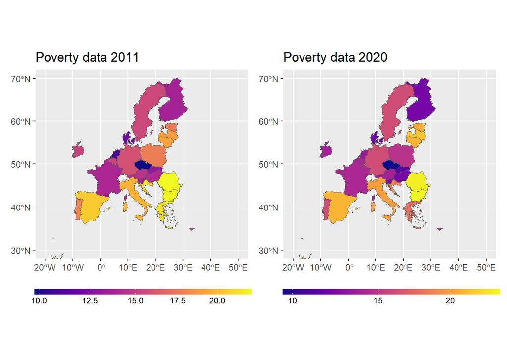

```r
format_sep <- function(x) format(x, big.mark = ' ')
#par(mfrow = c(1, 2))

P1<- ggplot(data = EU1) +
  geom_sf(aes(fill =  poverty_data_2011)) +
  scale_fill_viridis_c(option = "plasma", trans = "sqrt", guide = guide_colorbar(barwidth = 15), name = NULL,
                       labels = format_sep) +
  coord_sf(xlim = c(-20, 50), ylim = c(30, 70), expand = TRUE) +
  theme(legend.position = 'bottom',legend.text = element_text(size = 8),legend.title = element_text(size = 5)
        ,legend.key.size = unit(0.2, "cm")) +labs(title = "Poverty data 2011")

P2<- ggplot(data = EU1) +
  geom_sf(aes(fill =  poverty_data_2020)) +
  scale_fill_viridis_c(option = "plasma", trans = "sqrt", guide = guide_colorbar(barwidth = 15), name = NULL,
                       labels = format_sep) +
  coord_sf(xlim = c(-20, 50), ylim = c(30, 70), expand = TRUE) +
  theme(legend.position = 'bottom',legend.text = element_text(size = 8),legend.title = element_text(size = 5)
        ,legend.key.size = unit(0.2, "cm")) +labs(title = "Poverty data 2020")
P1 + P2
```

### the plot of minimum wage of EU countries in 2011 and 2020.

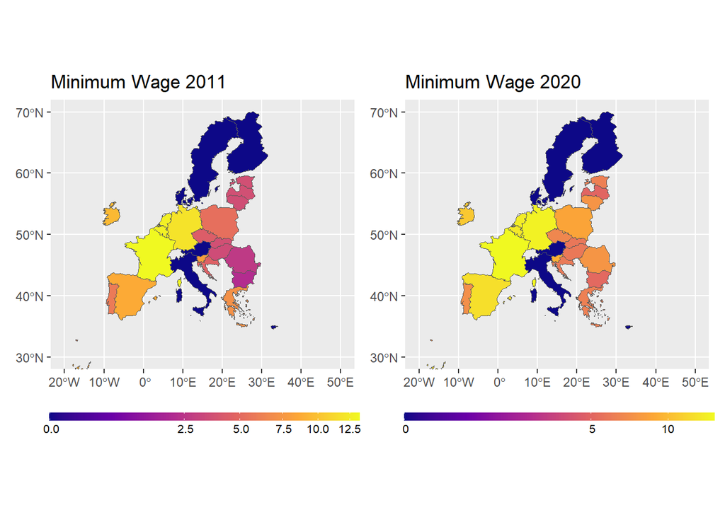

```r
P3<- ggplot(data = EU1) +
  geom_sf(aes(fill =  minimumWage_2011 )) +
  scale_fill_viridis_c(option = "plasma", trans = "sqrt", guide = guide_colorbar(barwidth = 15), name = NULL,
                       labels = format_sep) +
  coord_sf(xlim = c(-20, 50), ylim = c(30, 70), expand = TRUE) +
  theme(legend.position = 'bottom',legend.text = element_text(size = 8),legend.title = element_text(size = 5)
        ,legend.key.size = unit(0.2, "cm")) +labs(title = "Minimum Wage 2011")

P4<- ggplot(data = EU1) +
  geom_sf(aes(fill =  minimumWage_2020 )) +
  scale_fill_viridis_c(option = "plasma", trans = "sqrt", guide = guide_colorbar(barwidth = 15), name = NULL,
                       labels = format_sep) +
  coord_sf(xlim = c(-20, 50), ylim = c(30, 70), expand = TRUE) +
  theme(legend.position = 'bottom',legend.text = element_text(size = 8),legend.title = element_text(size = 5)
        ,legend.key.size = unit(0.2, "cm")) +labs(title = "Minimum Wage 2020")
P3 + P4
```

### the plot of overcrowding rate of EU countries in 2011 and 2020.

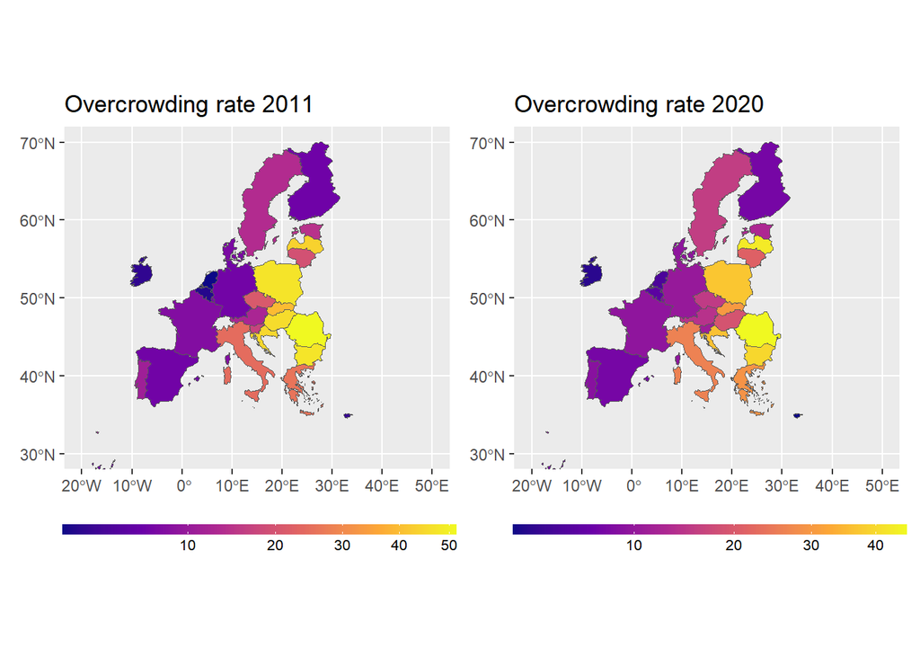

```r
P5<- ggplot(data = EU1) +
  geom_sf(aes(fill =  Overcrowding_rate_2011)) +
  scale_fill_viridis_c(option = "plasma", trans = "sqrt", guide = guide_colorbar(barwidth = 15), name = NULL,
                       labels = format_sep) +
  coord_sf(xlim = c(-20, 50), ylim = c(30, 70), expand = TRUE) +
  theme(legend.position = 'bottom',legend.text = element_text(size = 8),legend.title = element_text(size = 5)
        ,legend.key.size = unit(0.2, "cm")) +labs(title = "Overcrowding rate 2011")

P6<- ggplot(data = EU1) +
  geom_sf(aes(fill =  Overcrowding_rate_2020)) +
  scale_fill_viridis_c(option = "plasma", trans = "sqrt", guide = guide_colorbar(barwidth = 15), name = NULL,
                       labels = format_sep) +
  coord_sf(xlim = c(-20, 50), ylim = c(30, 70), expand = TRUE) +
  theme(legend.position = 'bottom',legend.text = element_text(size = 8),legend.title = element_text(size = 5)
        ,legend.key.size = unit(0.2, "cm")) +labs(title = "Overcrowding rate 2020")
P5+ P6
```

### the plot of unemployment rate of EU countries in 2011 and 2020.

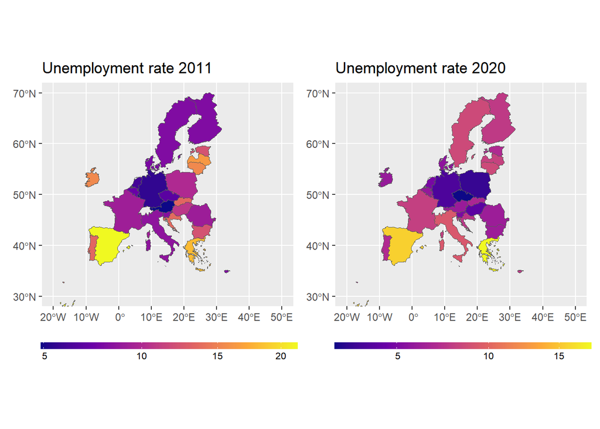

```r
P7<- ggplot(data = EU1) +
  geom_sf(aes(fill =  unemployment_rate_2011)) +
  scale_fill_viridis_c(option = "plasma", trans = "sqrt", guide = guide_colorbar(barwidth = 15), name = NULL,
                       labels = format_sep) +
  coord_sf(xlim = c(-20, 50), ylim = c(30, 70), expand = TRUE) +
  theme(legend.position = 'bottom',legend.text = element_text(size = 8),legend.title = element_text(size = 5)
        ,legend.key.size = unit(0.2, "cm")) +labs(title = "Unemployment rate 2011")

P8<- ggplot(data = EU1) +
  geom_sf(aes(fill =  unemployment_rate_2020)) +
  scale_fill_viridis_c(option = "plasma", trans = "sqrt", guide = guide_colorbar(barwidth = 15), name = NULL,
                       labels = format_sep) +
  coord_sf(xlim = c(-20, 50), ylim = c(30, 70), expand = TRUE) +
  theme(legend.position = 'bottom',legend.text = element_text(size = 8),legend.title = element_text(size = 5)
        ,legend.key.size = unit(0.2, "cm")) +labs(title = "Unemployment rate 2020")
P7 + P8
```

From the plots, we can see that the unemployment rate in 2020 is lower than in 2011.

## Model

```r
lm1 <- lm(poverty_data_2011 ~minimumWage_2011+Overcrowding_rate_2011+unemployment_rate_2011,data=EU1)
summary(lm1)
```

```
##
## Call:
## lm(formula = poverty_data_2011 ~ minimumWage_2011 + Overcrowding_rate_2011 +
##     unemployment_rate_2011, data = EU1)
##
## Residuals:
##     Min      1Q  Median      3Q     Max
## -5.9381 -1.4167  0.6379  1.6437  4.2905
##
## Coefficients:
##                        Estimate Std. Error t value    Pr(>|t|)
## (Intercept)            11.07136    1.55326   7.128 0.000000293 ***
## minimumWage_2011       -0.05268    0.12274  -0.429     0.67176
## Overcrowding_rate_2011  0.06645    0.03430   1.937     0.06508 .
## unemployment_rate_2011  0.40273    0.12805   3.145     0.00453 **
## ---
## Signif. codes:  0 '***' 0.001 '**' 0.01 '*' 0.05 '.' 0.1 ' ' 1
##
## Residual standard error: 2.662 on 23 degrees of freedom
## Multiple R-squared:  0.4746, Adjusted R-squared:  0.406
## F-statistic: 6.925 on 3 and 23 DF,  p-value: 0.001733
```

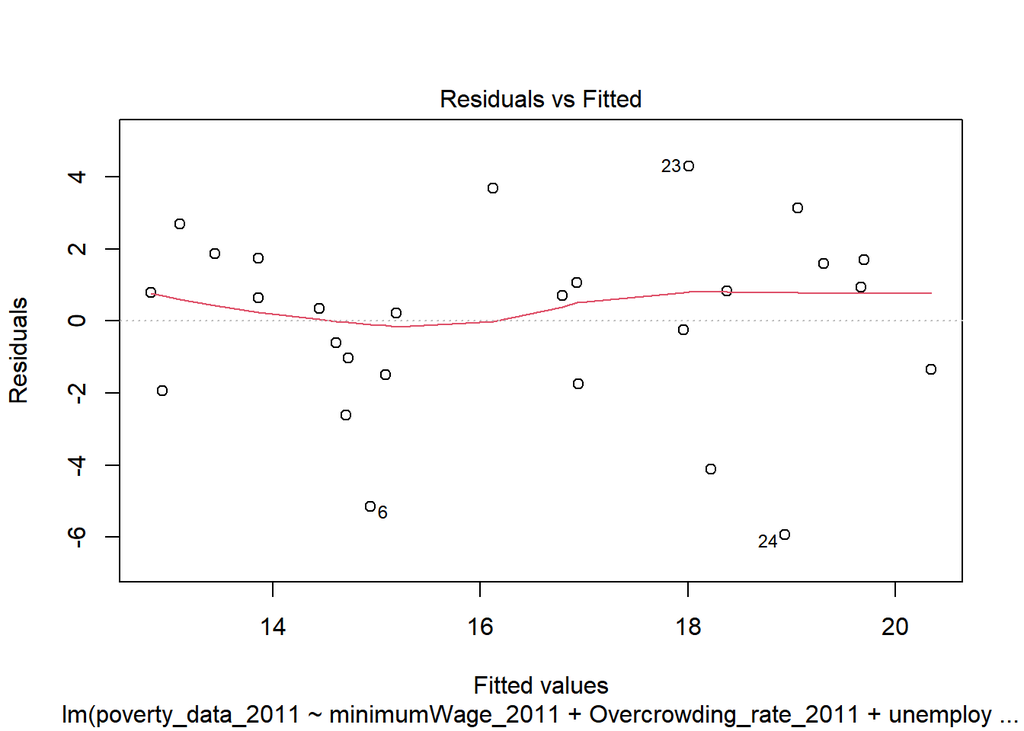

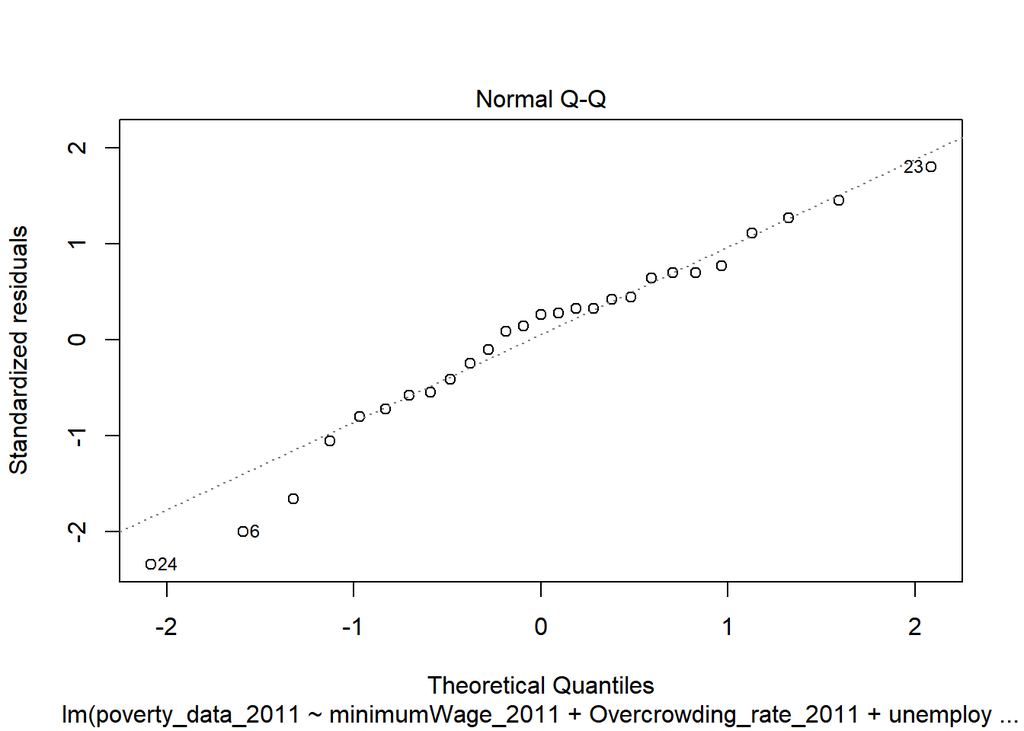

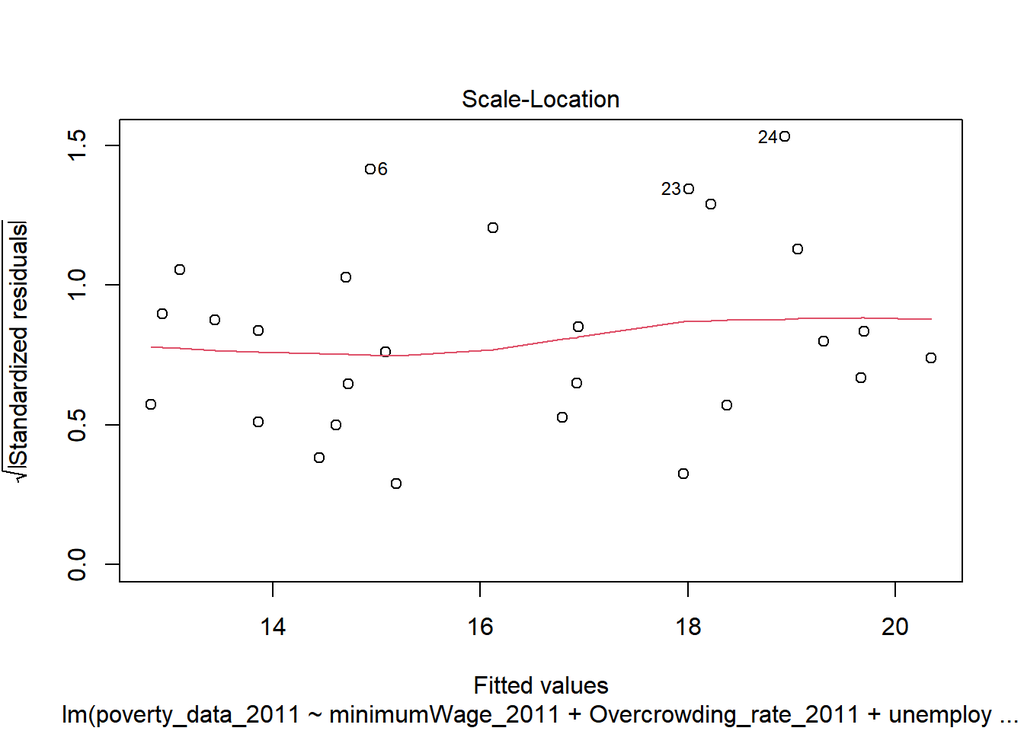

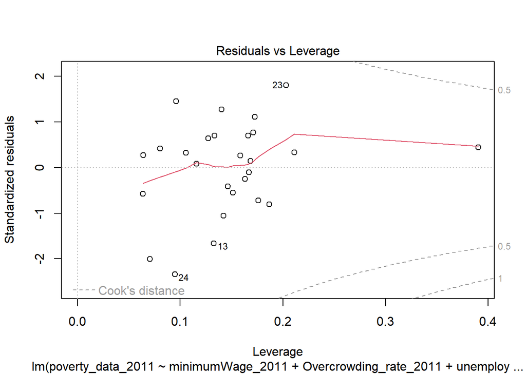

```r
plot(lm1)
```

```r
lm2 <- lm(poverty_data_2020 ~minimumWage_2020+Overcrowding_rate_2020+unemployment_rate_2020,data=EU1)
summary(lm2)
```

```
##
## Call:
## lm(formula = poverty_data_2020 ~ minimumWage_2020 + Overcrowding_rate_2020 +
##     unemployment_rate_2020, data = EU1)
##
## Residuals:
##     Min      1Q  Median      3Q     Max
## -6.4690 -2.0836 -0.2119  1.9969  5.2519
##
## Coefficients:
##                        Estimate Std. Error t value  Pr(>|t|)
## (Intercept)            10.01265    1.93381   5.178 0.0000301 ***
## minimumWage_2020        0.09094    0.13289   0.684    0.5006
## Overcrowding_rate_2020  0.14673    0.04789   3.064    0.0055 **
## unemployment_rate_2020  0.43333    0.19269   2.249    0.0344 *
## ---
## Signif. codes:  0 '***' 0.001 '**' 0.01 '*' 0.05 '.' 0.1 ' ' 1
##
## Residual standard error: 3.171 on 23 degrees of freedom
## Multiple R-squared:  0.4075, Adjusted R-squared:  0.3302
## F-statistic: 5.272 on 3 and 23 DF,  p-value: 0.006476
```

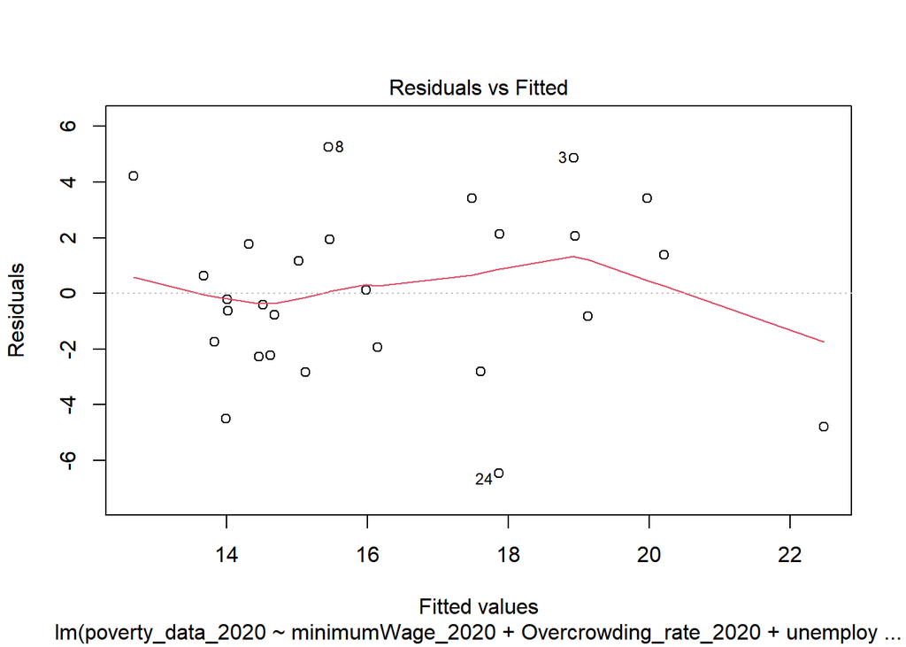

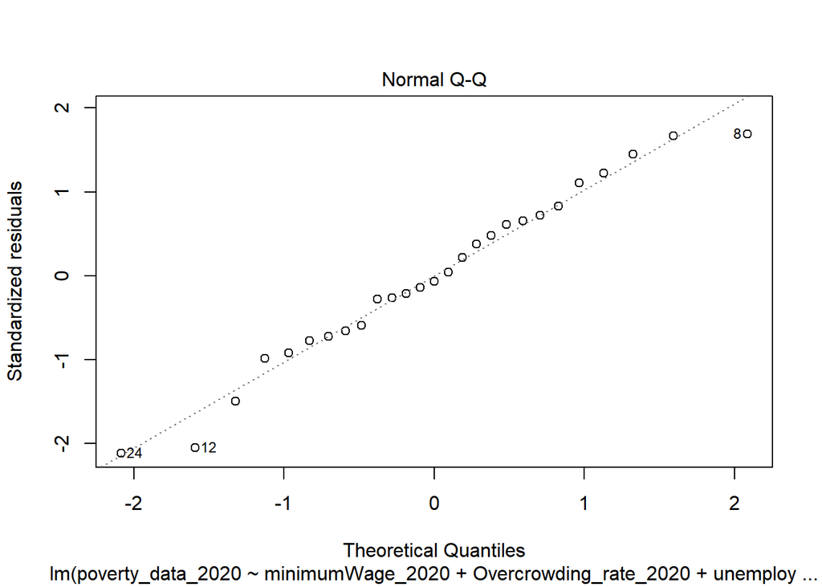

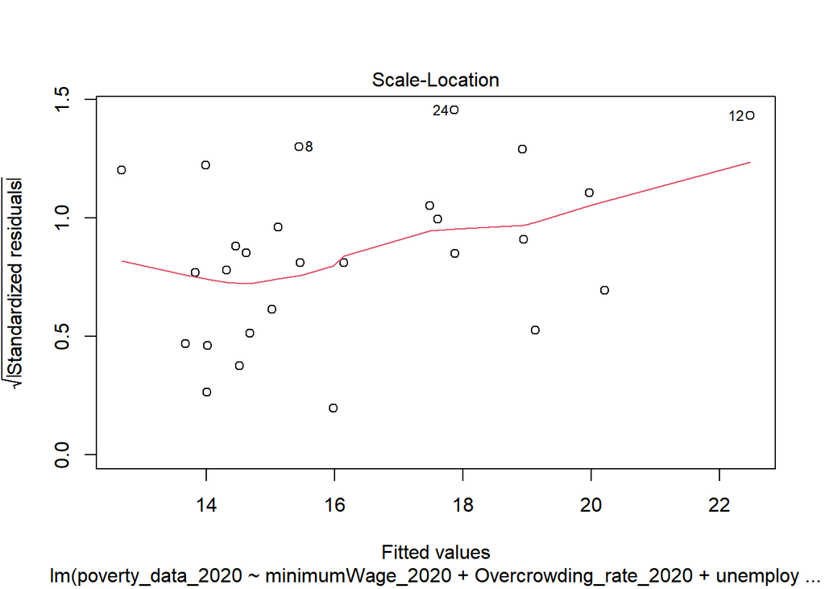

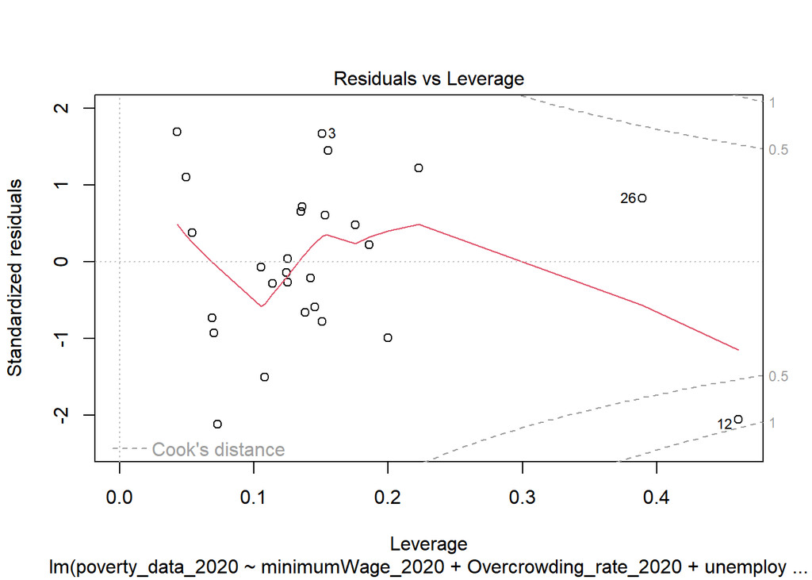

```r
plot(lm2)
```

In 2011 poverty rate had a strong relation with the unemployment rate, when the unemployment rate increased by 1%, the poverty rate increased by 0.40273% In 2020 poverty rate had a strong relation with the unemployment rate and overcrowding rate.when the unemployment rate increases by 1%, the poverty rate will increase by 0.43333% When the overcrowding rate increases by 1%, poverty rate will increase by 0.14673%.

## Spatial Correlation Analysis

```r
centroid <- st_centroid(EU1)
centroid_test <- centroid
centriod_test <- centroid %>%
  mutate(lonlat = st_as_text(geometry))
centriod_test <- centriod_test %>%
  separate(lonlat, into = c('cat',"lon", "lat"), sep = " ", convert = TRUE)
centriod_test$lon <- as.numeric(str_replace(centriod_test$lon, "\\(|\\)", ""))
centriod_test$lat <- as.numeric(str_replace(centriod_test$lat, "\\(|\\)", ""))
centriod_test
```

```
## Simple feature collection with 27 features and 74 fields
## Geometry type: POINT
## Dimension:     XY
## Bounding box:  xmin: -8.52813 ymin: 34.91709 xmax: 33.00581 ymax: 64.25514
## Geodetic CRS:  +proj=longlat +datum=WGS84 +no_defs +ellps=WGS84 +towgs84=0,0,0
## First 10 features:
##        name scalerank      featurecla labelrank     sovereignt sov_a3 adm0_dif
## 1   Austria         1 Admin-0 country         4        Austria    AUT        0
## 2   Belgium         1 Admin-0 country         2        Belgium    BEL        0
## 3  Bulgaria         1 Admin-0 country         4       Bulgaria    BGR        0
## 4   Croatia         1 Admin-0 country         6        Croatia    HRV        0
## 5    Cyprus         1 Admin-0 country         5         Cyprus    CYP        0
## 6   Czechia         1 Admin-0 country         5 Czech Republic    CZE        0
## 7   Denmark         1 Admin-0 country         4        Denmark    DN1        1
## 8   Estonia         1 Admin-0 country         6        Estonia    EST        0
```

[output cut: 134 more lines]

```r
poverty_data_2011 <- centriod_test %>% select('name','poverty_data_2011','lon','lat')
poverty_coordinates <- st_coordinates(poverty_data_2011)
poverty_nb <- knn2nb(knearneigh(poverty_coordinates, k = 5))
```

```r
poverty_nb_Matrix <- nb2listw(poverty_nb, style = "W")

moranTestpoverty <- moran.test(poverty_data_2011$poverty_data_2011, poverty_nb_Matrix)
moranTestpoverty
```

```
##
##  Moran I test under randomisation
##
## data:  poverty_data_2011$poverty_data_2011
## weights: poverty_nb_Matrix
##
## Moran I statistic standard deviate = 1.8173, p-value = 0.03459
## alternative hypothesis: greater
## sample estimates:
## Moran I statistic       Expectation          Variance
##       0.139194328      -0.038461538       0.009556673
```

The Moran’s I test is a measure of spatial autocorrelation, which assesses whether the observed values for a variable are clustered, dispersed, or randomly distributed across space. The Moran’s I statistic ranges from -1 to 1, with positive values indicating positive spatial autocorrelation (clustering), negative values indicating negative spatial autocorrelation (dispersion), and values close to zero indicating a random spatial pattern.

The p-value is 0.03459, which is less than the commonly used significance level of 0.05. This suggests that there is evidence to reject the null hypothesis of spatial randomness.Alternative hypothesis: The alternative hypothesis is stated as “greater.” This means that you are testing for positive spatial autocorrelation (clustering).This shows that countries with high poverty rates are relatively concentrated geographically, which is indeed the case in real life. The western region is more developed than the eastern region.

```r
poverty_data_2020 <- centriod_test %>% select('name','poverty_data_2020','lon','lat')
poverty_coordinates <- st_coordinates(poverty_data_2020)
poverty_nb <- knn2nb(knearneigh(poverty_coordinates, k = 5))
```

```r
poverty_nb_Matrix <- nb2listw(poverty_nb, style = "W")

moranTestpoverty <- moran.test(poverty_data_2020$poverty_data_2020, poverty_nb_Matrix)
moranTestpoverty
```

```
##
##  Moran I test under randomisation
##
## data:  poverty_data_2020$poverty_data_2020
## weights: poverty_nb_Matrix
##
## Moran I statistic standard deviate = 1.3327, p-value = 0.09132
## alternative hypothesis: greater
## sample estimates:
## Moran I statistic       Expectation          Variance
##       0.091678541      -0.038461538       0.009536226
```

## Conclusion

To sum up, through spatial data analysis of EU countries, we know that the unemployment rate greatly affects the poverty rate. After several years of development, the EU’s living standards have increased as a whole. By considering the structure of geographic space, we can better understand the relationships between data, especially for phenomena that are geographically dependent.